# Figure 3

Survival curves

Claire, Marceaux, Ilariya Tarasova

August 28, 2025

# 1 Preparation

Here we are focusing on survival analysis:

- OS = overall survival;
- RFS = recurrence-free survival (available only for CM cohort)

## 1.1 Read the data

```r
> patient_survival_Enfield <- readRDS(file="../../data/Enfield_patient_survival.rds")
> Percentage_Sorin_cohort <- readRDS("../../data/Percentage_Sorin_cohort.rds")
> patient_counts_CM <- readRDS(file="../../data/CM_patient_counts_no_compartment_all_FM_TRM_df.rds")
>
> CM_LUAD_immune_subgr <- readRDS(file = "../../data/CM_LUAD_immune_subgroups.rds")
> Sorin_LUAD_immune_subgr <- readRDS(file = "../../data/Sorin_LUAD_immune_subgroups.rds")
> Enfield_LUAD_immune_subgr <- readRDS(file = "../../data/Enfield_LUAD_immune_subgroups.rds")
>
> patients_with_high_Neutr <- readRDS(file = "../interim_data/patients_with_high_Neutr_Sorin.rds")
```

## 1.2 Source the functions

```r
> source('../../src/plot_heatmap_immune_subgroups.R')
> #source the colors
> immune_subgroup_colors <- readRDS("../../data/immune_subgroup_colors.rds")
```

## 1.3 Set the output folder

```r
> output_folder <- "../plots/"
```

# 2 Functions

## 2.1 Plotting Kaplan Meir curves

```r
> survival_plot <- function(fit, data_fr, column, survival_type, output_folder, title_plot){
+   cols <- switch(column,
+                  "high_in_Neutr_subgr" = c(M_Neutr_high = "#0868ac",
+                                            M_Neutr_low = "#43a2ca",
+                                            LM = "goldenrod1", L = "tomato1"),
+                  "immuneSubgroups" = immune_subgroup_colors,
+                  "ThCD14_high" = c("magenta", "darkmagenta"))
+
+   #show_risk_tbl <- switch(survival_type,
+   #                        "OS" = F,
+   #                        "RFS" = T)
+
+   plot_file_name = paste0(output_folder, paste0(title_plot, "_", survival_type, "_",column), ".jpg")
+   print(ggsurvplot(fit,
+              palette = cols,
+              #risk.table = show_risk_tbl,
+              pval = T,
+              xlab = "Time in Years",
+              ylab = "Survival Probability",
+              title = paste(title_plot, survival_type),
+               legend.title = "Immune subgroups",
+              legend.labs = levels(data_fr[[column]])
+              )
+     )
+   ggsave(file = plot_file_name,
+          width = 7, height = 7, units = "in")
+ }
```

## 2.2 Main function with stats

```r
> do_survival_analysis <- function(data_fr, column, survival_type, output_folder, plot_title){
+   y <- switch(survival_type,
+               "OS" = "Surv(OS_years, Death)",
+               "RFS" = "Surv(RFS_years, Relapse)")
+   x <- column
+   form = as.formula(paste(y, "~", x))
+   fit <- surv_fit(form, data = data_fr)
+   survival_plot(fit, data_fr, column, survival_type, output_folder, plot_title)
+
+   summary_fit <- summary(fit)
+   # Tidy data frame with medians per group
+   medians_df <- data.frame(
+     group = rownames(summary_fit$table),
+     median_survival = summary_fit$table[, "median"],
+     lower_ci = summary_fit$table[, "0.95LCL"],
+     upper_ci = summary_fit$table[, "0.95UCL"]
+   )
+   print(medians_df)
+
+   # need to change reference level for stats
+   if(column == "immuneSubgroups"){
+     data_fr$immuneSubgroups <- factor(data_fr$immuneSubgroups, levels = c("M", "LM", "L"))
+   }
+   coxfit <- coxph(form, data = data_fr)
+
+   return(summary(coxfit))
+ }
```

The `survfit()` function gives only one p-value from log rank test (two groups). To perform test between multiple groups, I used Cox Proportional Hazards regression model, implemented in `coxph()` function of the *survival* package. Taken from [here](https://www.biostars.org/p/401657/).

The hazard ratios (HRs) are given by:

+exp(coef), HR +exp(-coef), HR flipped the other way +lower .95, lower 95% CI of the HR +upper .95, upper 95% CI of the HR

# 3 CM cohort

## 3.1 Prepare the table

```r
> survival_CM_cohort <- patient_counts_CM[, c("Patient", "Cancer Type", 'Date of death',
+                                             'OS (days)', 'Vital status', 'RFS (days)', 'Relapse')]
> survival_CM_cohort <- survival_CM_cohort[!duplicated(survival_CM_cohort),]
> survival_CM_LUAD <- survival_CM_cohort[survival_CM_cohort$`Cancer Type` == "LUAD",]
> survival_CM_LUAD$immuneSubgroups <- CM_LUAD_immune_subgr$cluster[match(survival_CM_LUAD$Patient,
+                                                                                        CM_LUAD_immune_subgr$patient)]
>
> #new_col_names <- c("OS_years", "Death", "RFS_years", "Relapse")
> survival_CM_LUAD$OS_years <- round(survival_CM_LUAD$'OS (days)'/365.25, 2)
> survival_CM_LUAD$Death <- as.logical(survival_CM_LUAD$`Vital status`) # no invert here!
> survival_CM_LUAD$RFS_years <- round(survival_CM_LUAD$'RFS (days)'/365.25, 2)
> # sanity check here is NA in 'Date of death' column!
> head(survival_CM_LUAD)
```

```
    Patient Cancer Type Date of death OS (days) Vital status RFS (days) Relapse
54 14MH1032        LUAD    2016-10-25       797         TRUE        757    TRUE
15 12MH0925        LUAD    2015-01-22       883         TRUE        309    TRUE
49 14MH0636        LUAD          <NA>      2249        FALSE        548    TRUE
59 15MH0258        LUAD    2018-06-04       940         TRUE         69    TRUE
50 14MH0637        LUAD          <NA>      2249        FALSE       1297   FALSE
40 13MH1064        LUAD    2015-05-16       570         TRUE        296    TRUE
   immuneSubgroups OS_years Death RFS_years
54              LM     2.18  TRUE      2.07
15               L     2.42  TRUE      0.85
49               M     6.16 FALSE      1.50
59               M     2.57  TRUE      0.19
50              LM     6.16 FALSE      3.55
40               M     1.56  TRUE      0.81
```

```r
> survival_CM_LUAD$immuneSubgroups <- factor(survival_CM_LUAD$immuneSubgroups, levels = c("L", "LM", "M"))
```

## 3.2 OS LUAD

```r
> table(survival_CM_LUAD$immuneSubgroups)
```

```
 L LM  M
19 16  9
```

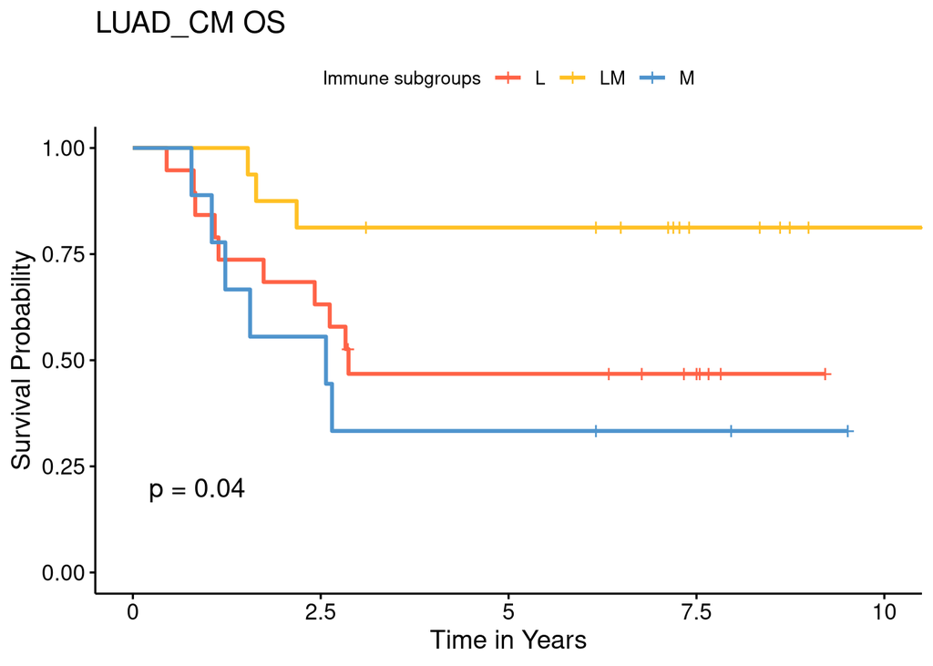

```
                                group median_survival lower_ci upper_ci
immuneSubgroups=L   immuneSubgroups=L            2.87     2.42       NA
immuneSubgroups=LM immuneSubgroups=LM              NA       NA       NA
immuneSubgroups=M   immuneSubgroups=M            2.57     1.23       NA
```

```
Call:
coxph(formula = form, data = data_fr)

  n= 44, number of events= 19

                     coef exp(coef) se(coef)      z Pr(>|z|)
immuneSubgroupsLM -1.6403    0.1939   0.7094 -2.312   0.0208 *
immuneSubgroupsL  -0.3787    0.6848   0.5177 -0.731   0.4645
---
Signif. codes:  0 '***' 0.001 '**' 0.01 '*' 0.05 '.' 0.1 ' ' 1

                  exp(coef) exp(-coef) lower .95 upper .95
immuneSubgroupsLM    0.1939      5.157   0.04828    0.7789
immuneSubgroupsL     0.6848      1.460   0.24826    1.8888

Concordance= 0.658  (se = 0.055 )
Likelihood ratio test= 6.9  on 2 df,   p=0.03
Wald test            = 5.48  on 2 df,   p=0.06
Score (logrank) test = 6.44  on 2 df,   p=0.04
```

```r
> do_survival_analysis(survival_CM_LUAD, "immuneSubgroups", "OS",
+                      output_folder, plot_title = "LUAD_CM")
```

## 3.3 RFS LUAD

```r
> table(is.na(survival_CM_LUAD$RFS_years), survival_CM_LUAD$immuneSubgroups)
```

```
         L LM  M
  FALSE 12 15  9
  TRUE   7  1  0
```

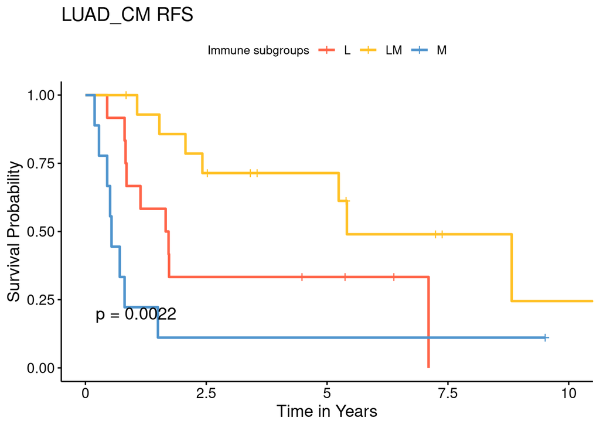

```
                                group median_survival lower_ci upper_ci
immuneSubgroups=L   immuneSubgroups=L            1.69     0.85       NA
immuneSubgroups=LM immuneSubgroups=LM            5.41     5.24       NA
immuneSubgroups=M   immuneSubgroups=M            0.54     0.45       NA
```

```
Call:
coxph(formula = form, data = data_fr)

  n= 36, number of events= 24
   (8 observations deleted due to missingness)

                     coef exp(coef) se(coef)      z Pr(>|z|)
immuneSubgroupsLM -1.7404    0.1754   0.5358 -3.248  0.00116 **
immuneSubgroupsL  -0.8615    0.4225   0.5071 -1.699  0.08936 .
---
Signif. codes:  0 '***' 0.001 '**' 0.01 '*' 0.05 '.' 0.1 ' ' 1

                  exp(coef) exp(-coef) lower .95 upper .95
immuneSubgroupsLM    0.1754      5.700   0.06138    0.5015
immuneSubgroupsL     0.4225      2.367   0.15637    1.1416

Concordance= 0.75  (se = 0.046 )
Likelihood ratio test= 10.41  on 2 df,   p=0.005
Wald test            = 10.55  on 2 df,   p=0.005
Score (logrank) test = 12.33  on 2 df,   p=0.002
```

```r
> survival_CM_LUAD$Relapse <- as.logical(survival_CM_LUAD$Relapse)
> do_survival_analysis(survival_CM_LUAD, "immuneSubgroups", "RFS",
+                      output_folder, plot_title = "LUAD_CM")
```

```r
> surv_obj <- Surv(time = survival_CM_LUAD$RFS_years, event = as.logical(survival_CM_LUAD$Relapse))
> fit_km <- survfit(surv_obj ~ immuneSubgroups, data = survival_CM_LUAD)
> summary(fit_km)$table
```

```
                   records n.max n.start events    rmean se(rmean) median
immuneSubgroups=L       12    12      12      9 3.132500 0.8172015   1.69
immuneSubgroups=LM      15    15      15      7 6.449694 1.0277361   5.41
immuneSubgroups=M        9     9       9      8 1.727778 1.0477816   0.54
                   0.95LCL 0.95UCL
immuneSubgroups=L     0.85      NA
immuneSubgroups=LM    5.24      NA
immuneSubgroups=M     0.45      NA
```

## 3.4 CD4CD14 high vs low in LLM

```r
> Percentage_CM_cohort_Tumour_LLM_CD4CD14 <- readRDS("../../data/Percentage_CM_cohort_Tumour_LLM_CD4CD14.rds")
> survival_CM_LUAD_LLM <- survival_CM_LUAD[survival_CM_LUAD$immuneSubgroups != "M",]
> survival_CM_LUAD_LLM$ThCD14_high <- Percentage_CM_cohort_Tumour_LLM_CD4CD14$CD4CD14_high[match(survival_CM_LUAD_LLM$Patient,
+                                                                                                 Percentage_CM_cohort_Tumour_LLM_CD4CD14$Patient)]
> table(survival_CM_LUAD_LLM$ThCD14_high, useNA = "ifany")
```

```
FALSE  TRUE  <NA>
    6     3    26
```

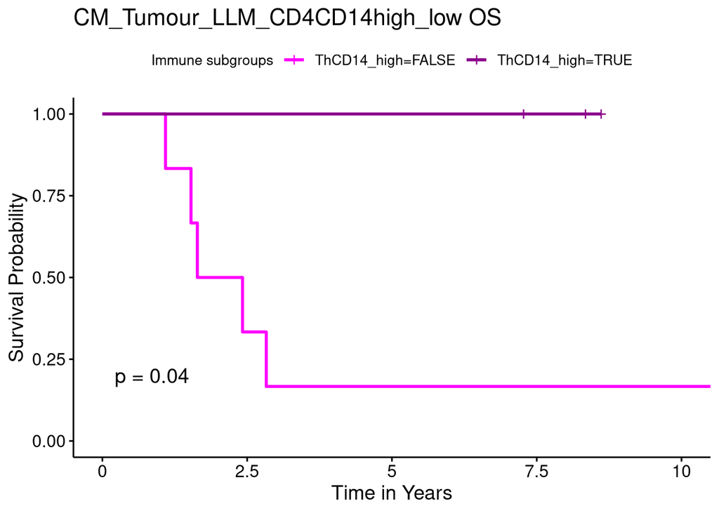

```
                              group median_survival lower_ci upper_ci
ThCD14_high=FALSE ThCD14_high=FALSE            2.03     1.53       NA
ThCD14_high=TRUE   ThCD14_high=TRUE              NA       NA       NA
```

```
Call:
coxph(formula = form, data = data_fr)

  n= 9, number of events= 5
   (26 observations deleted due to missingness)

                      coef  exp(coef)   se(coef)      z Pr(>|z|)
ThCD14_highTRUE -2.110e+01  6.843e-10  1.833e+04 -0.001    0.999

                exp(coef) exp(-coef) lower .95 upper .95
ThCD14_highTRUE 6.843e-10  1.461e+09         0       Inf

Concordance= 0.75  (se = 0.091 )
Likelihood ratio test= 6.09  on 1 df,   p=0.01
Wald test            = 0  on 1 df,   p=1
Score (logrank) test = 4.2  on 1 df,   p=0.04
```

```r
> do_survival_analysis(survival_CM_LUAD_LLM,
+                      "ThCD14_high", "OS", output_folder, "CM_Tumour_LLM_CD4CD14high_low")
```

# 4 Sorin

## 4.1 Prepare the table

```r
> survival_Sorin_cohort <- Percentage_Sorin_cohort[,c("Patient", "OS_years", "Death")]
> survival_Sorin_cohort <- survival_Sorin_cohort[!duplicated(survival_Sorin_cohort),]
> survival_Sorin_cohort$immuneSubgroups <- Sorin_LUAD_immune_subgr$cluster[match(survival_Sorin_cohort$Patient,
+                                                                                        Sorin_LUAD_immune_subgr$patient)]
> table(survival_Sorin_cohort$immuneSubgroups)
```

```
  L  LM   M
113 188 115
```

```r
> survival_Sorin_cohort$immuneSubgroups <- factor(survival_Sorin_cohort$immuneSubgroups,
+                                                 levels = c("L", "LM", "M"))
```

## 4.2 OS (E (i))

```r
> table(survival_Sorin_cohort$immuneSubgroups)
```

```
  L  LM   M
113 188 115
```

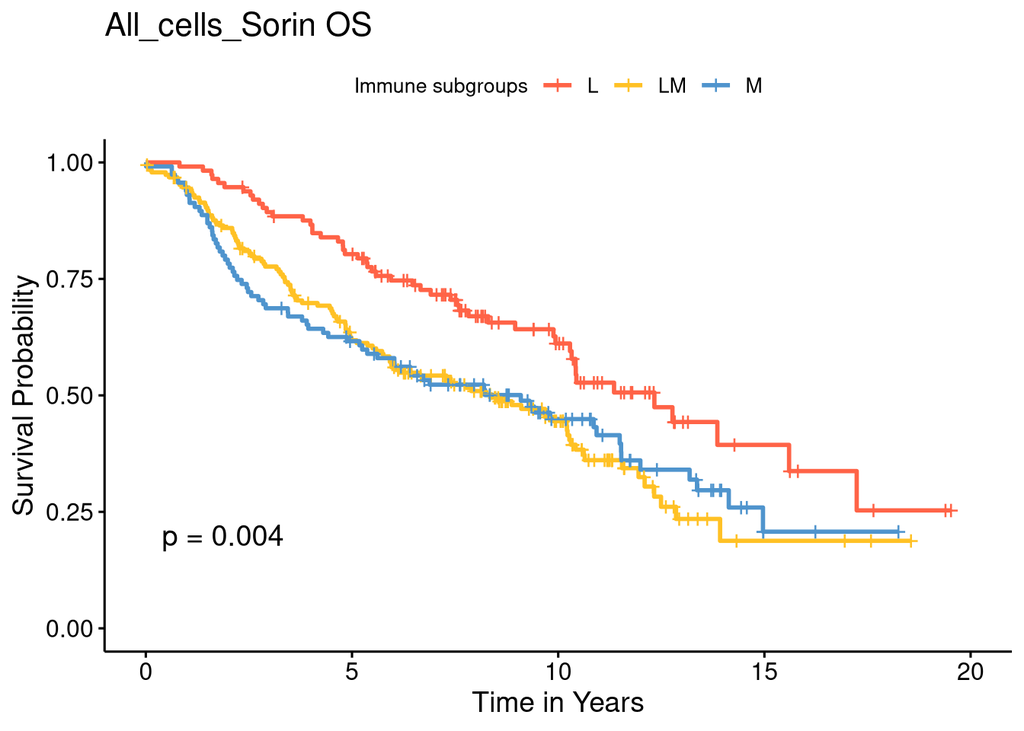

```
                                group median_survival lower_ci upper_ci
immuneSubgroups=L   immuneSubgroups=L          12.332   10.325       NA
immuneSubgroups=LM immuneSubgroups=LM           8.386    5.952   10.270
immuneSubgroups=M   immuneSubgroups=M           9.093    5.615   11.524
```

```
Call:
coxph(formula = form, data = data_fr)

  n= 416, number of events= 230

                      coef exp(coef) se(coef)      z Pr(>|z|)
immuneSubgroupsLM  0.03767   1.03839  0.15373  0.245  0.80643
immuneSubgroupsL  -0.50252   0.60500  0.18558 -2.708  0.00677 **
---
Signif. codes:  0 '***' 0.001 '**' 0.01 '*' 0.05 '.' 0.1 ' ' 1

                  exp(coef) exp(-coef) lower .95 upper .95
immuneSubgroupsLM     1.038      0.963    0.7683    1.4035
immuneSubgroupsL      0.605      1.653    0.4205    0.8704

Concordance= 0.557  (se = 0.018 )
Likelihood ratio test= 11.84  on 2 df,   p=0.003
Wald test            = 10.81  on 2 df,   p=0.004
Score (logrank) test = 11.06  on 2 df,   p=0.004
```

```r
> do_survival_analysis(survival_Sorin_cohort, "immuneSubgroups", "OS",
+                      output_folder, plot_title = "All_cells_Sorin")
```

## 4.3 Neutrophils high vs low in M (E (ii))

```r
> survival_Sorin_cohort$high_in_Neutr <- ifelse(survival_Sorin_cohort$Patient %in% patients_with_high_Neutr,
+                                               "yes", "no")
> survival_Sorin_cohort$high_in_Neutr_subgr <- as.character(survival_Sorin_cohort$immuneSubgroups)
> # We are interested in patients from M subgroup that are high in Neutrophils
> survival_Sorin_cohort$high_in_Neutr_subgr <- ifelse(survival_Sorin_cohort$high_in_Neutr_subgr == "M" &
+                                                   survival_Sorin_cohort$high_in_Neutr == "yes",
+                                               "M_Neutr_high", survival_Sorin_cohort$high_in_Neutr_subgr)
> survival_Sorin_cohort$high_in_Neutr_subgr <- ifelse(survival_Sorin_cohort$high_in_Neutr_subgr == "M" &
+                                                   survival_Sorin_cohort$high_in_Neutr == "no",
+                                               "M_Neutr_low", survival_Sorin_cohort$high_in_Neutr_subgr)
> # the order of the levels are in the way that the first one is a reference level
> survival_Sorin_cohort$high_in_Neutr_subgr <- factor(survival_Sorin_cohort$high_in_Neutr_subgr,
+                                                     levels = c("M_Neutr_high" ,"M_Neutr_low","LM", "L"))
```

```r
> table(survival_Sorin_cohort$high_in_Neutr_subgr)
```

```
M_Neutr_high  M_Neutr_low           LM            L
          20           95          188          113
```

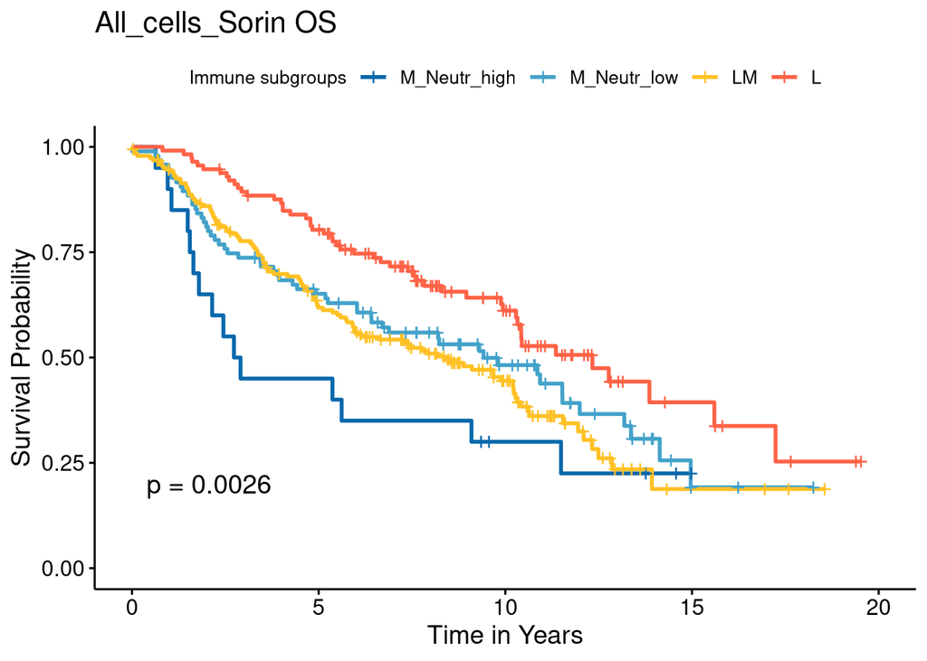

```
                                                            group
high_in_Neutr_subgr=M_Neutr_high high_in_Neutr_subgr=M_Neutr_high
high_in_Neutr_subgr=M_Neutr_low   high_in_Neutr_subgr=M_Neutr_low
high_in_Neutr_subgr=LM                     high_in_Neutr_subgr=LM
high_in_Neutr_subgr=L                       high_in_Neutr_subgr=L
                                 median_survival lower_ci upper_ci
high_in_Neutr_subgr=M_Neutr_high           2.819    1.793       NA
high_in_Neutr_subgr=M_Neutr_low            9.416    6.415   13.186
high_in_Neutr_subgr=LM                     8.386    5.952   10.270
high_in_Neutr_subgr=L                     12.332   10.325       NA
```

```
Call:
coxph(formula = form, data = data_fr)

  n= 416, number of events= 230

                                  coef exp(coef) se(coef)      z Pr(>|z|)
high_in_Neutr_subgrM_Neutr_low -0.4860    0.6151   0.2917 -1.666  0.09572 .
high_in_Neutr_subgrLM          -0.3630    0.6956   0.2765 -1.313  0.18923
high_in_Neutr_subgrL           -0.9031    0.4053   0.2954 -3.058  0.00223 **
---
Signif. codes:  0 '***' 0.001 '**' 0.01 '*' 0.05 '.' 0.1 ' ' 1

                               exp(coef) exp(-coef) lower .95 upper .95
high_in_Neutr_subgrM_Neutr_low    0.6151      1.626    0.3473    1.0895
high_in_Neutr_subgrLM             0.6956      1.438    0.4045    1.1959
high_in_Neutr_subgrL              0.4053      2.467    0.2272    0.7231

Concordance= 0.577  (se = 0.018 )
Likelihood ratio test= 14.36  on 3 df,   p=0.002
Wald test            = 13.83  on 3 df,   p=0.003
Score (logrank) test = 14.24  on 3 df,   p=0.003
```

```r
> do_survival_analysis(survival_Sorin_cohort, "high_in_Neutr_subgr", "OS",
+                      output_folder, "All_cells_Sorin")
```

## 4.4 CD4CD14 high vs low (Fig 5)

First we will read the percentage of CD4CD14 that was calculated for Figure 2 (in tumour only, all patients).

```r
> Percentage_Sorin_cohort_Tumour_Th <- readRDS("../../Figure2/interim_data/Percentage_Sorin_cohort_Tumour_MLLM_CD4CD14.rds")
> threshold_Sorin_CD4CD14_Tumour <- mean(Percentage_Sorin_cohort_Tumour_Th$Percentage)
> threshold_Sorin_CD4CD14_Tumour
```

```
[1] 30.41922
```

```r
> #30.4
> Percentage_Sorin_cohort_Tumour_Th$ThCD14_high <- Percentage_Sorin_cohort_Tumour_Th$Percentage > threshold_Sorin_CD4CD14_Tumour
> survival_Sorin_cohort$ThCD14_high <- Percentage_Sorin_cohort_Tumour_Th$ThCD14_high[match(survival_Sorin_cohort$Patient,
+                                                                                        Percentage_Sorin_cohort_Tumour_Th$Patient)]
> survival_Sorin_cohort$Percentage <- Percentage_Sorin_cohort_Tumour_Th$Percentage[match(survival_Sorin_cohort$Patient,
+                                                                                        Percentage_Sorin_cohort_Tumour_Th$Patient)]
> print("Number of patients in each immune subgroups split by the ThCD14 status (TRUE = high)")
```

```
[1] "Number of patients in each immune subgroups split by the ThCD14 status (TRUE = high)"
```

```r
> table(survival_Sorin_cohort$immuneSubgroups, survival_Sorin_cohort$ThCD14_high)
```

```
     FALSE TRUE
  L     64   47
  LM   101   75
  M     59   42
```

Do the mean of percentages of CD14 positive CD4 T cells differ in different immune subgroups?

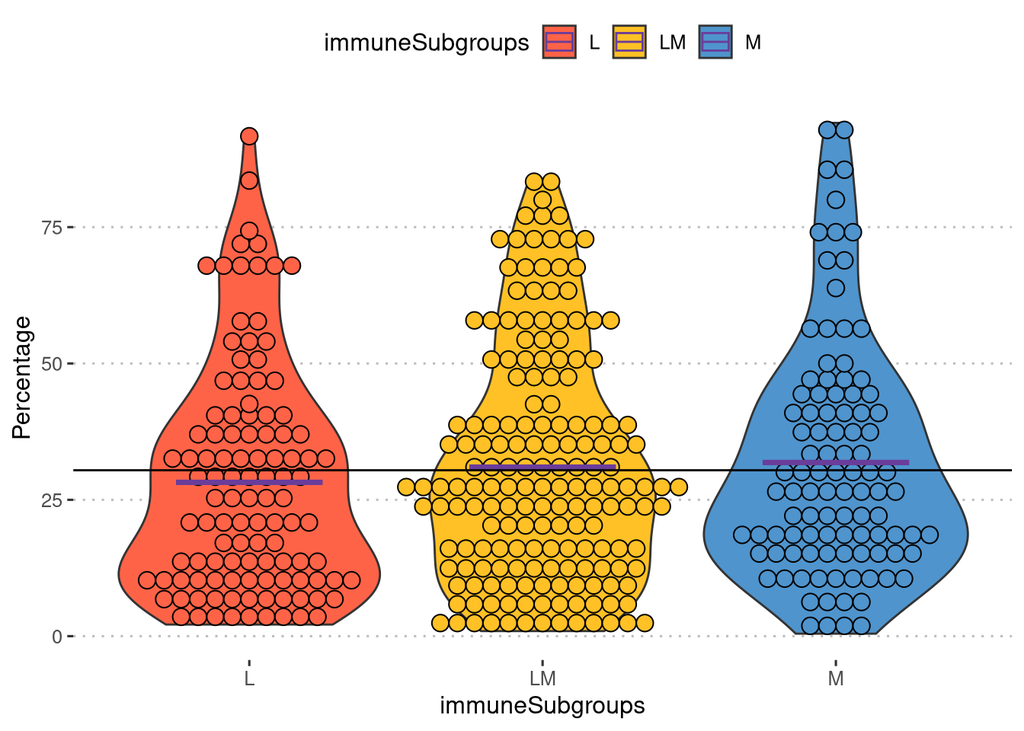

```r
> ggplot(survival_Sorin_cohort, aes(x=immuneSubgroups, y=Percentage, fill=immuneSubgroups)) +
+   geom_violin(trim = T)+
+   geom_dotplot(binaxis='y', stackdir='center')+
+   scale_fill_manual(values = immune_subgroup_colors)+
+   stat_summary(fun.y=mean, geom="crossbar",width = 0.5, color="#6a3d9a")+
+   geom_hline(aes(yintercept = threshold_Sorin_CD4CD14_Tumour))+
+   theme_pubclean()
```

Seems like no.

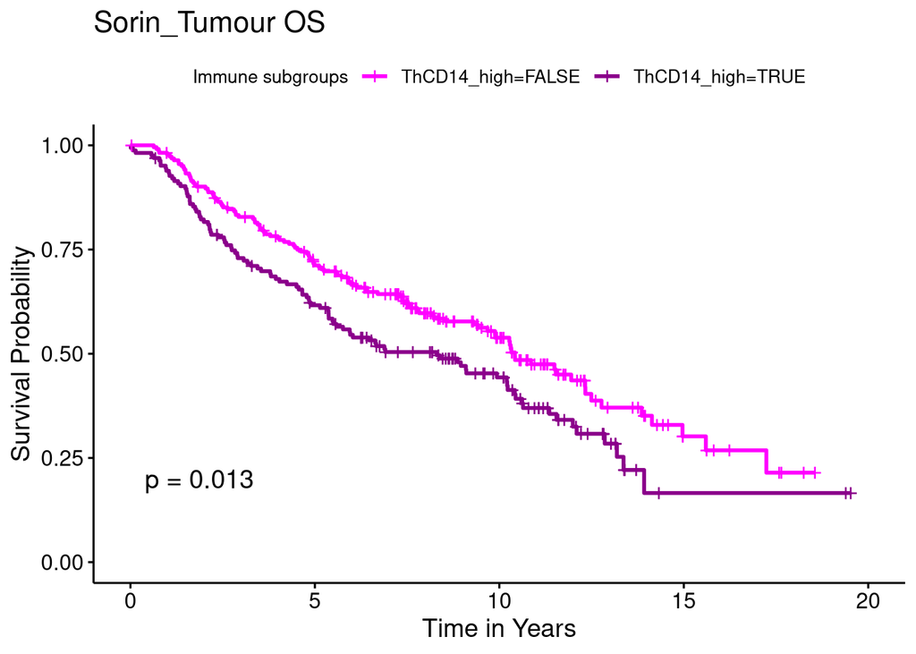

```
                              group median_survival lower_ci upper_ci
ThCD14_high=FALSE ThCD14_high=FALSE          10.423    9.416   12.493
ThCD14_high=TRUE   ThCD14_high=TRUE           8.304    5.498   10.420
```

```
Call:
coxph(formula = form, data = data_fr)

  n= 388, number of events= 213
   (28 observations deleted due to missingness)

                  coef exp(coef) se(coef)     z Pr(>|z|)
ThCD14_highTRUE 0.3391    1.4036   0.1377 2.462   0.0138 *
---
Signif. codes:  0 '***' 0.001 '**' 0.01 '*' 0.05 '.' 0.1 ' ' 1

                exp(coef) exp(-coef) lower .95 upper .95
ThCD14_highTRUE     1.404     0.7124     1.072     1.839

Concordance= 0.548  (se = 0.018 )
Likelihood ratio test= 6  on 1 df,   p=0.01
Wald test            = 6.06  on 1 df,   p=0.01
Score (logrank) test = 6.12  on 1 df,   p=0.01
```

```r
> do_survival_analysis(survival_Sorin_cohort, "ThCD14_high", "OS",
+                      output_folder, "Sorin_Tumour")
```

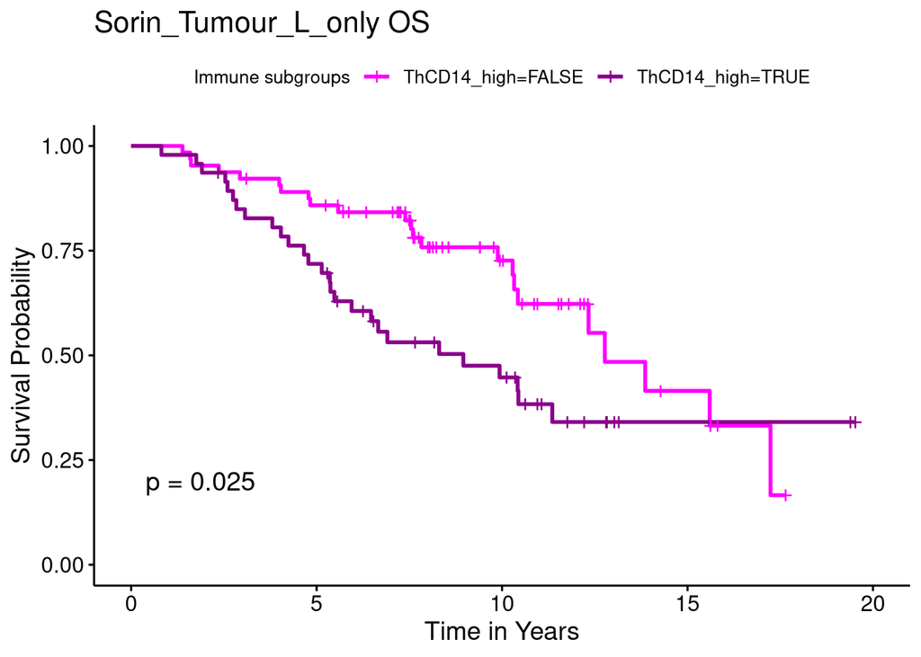

```
                              group median_survival lower_ci upper_ci
ThCD14_high=FALSE ThCD14_high=FALSE          12.770   10.426       NA
ThCD14_high=TRUE   ThCD14_high=TRUE           8.956    5.944       NA
```

```
Call:
coxph(formula = form, data = data_fr)

  n= 111, number of events= 50
   (2 observations deleted due to missingness)

                  coef exp(coef) se(coef)     z Pr(>|z|)
ThCD14_highTRUE 0.6273    1.8725   0.2850 2.201   0.0278 *
---
Signif. codes:  0 '***' 0.001 '**' 0.01 '*' 0.05 '.' 0.1 ' ' 1

                exp(coef) exp(-coef) lower .95 upper .95
ThCD14_highTRUE     1.873      0.534     1.071     3.274

Concordance= 0.608  (se = 0.038 )
Likelihood ratio test= 4.85  on 1 df,   p=0.03
Wald test            = 4.84  on 1 df,   p=0.03
Score (logrank) test = 5  on 1 df,   p=0.03
```

```r
> do_survival_analysis(survival_Sorin_cohort[survival_Sorin_cohort$immuneSubgroups == "L",],
+                      "ThCD14_high", "OS", output_folder, "Sorin_Tumour_L_only")
```

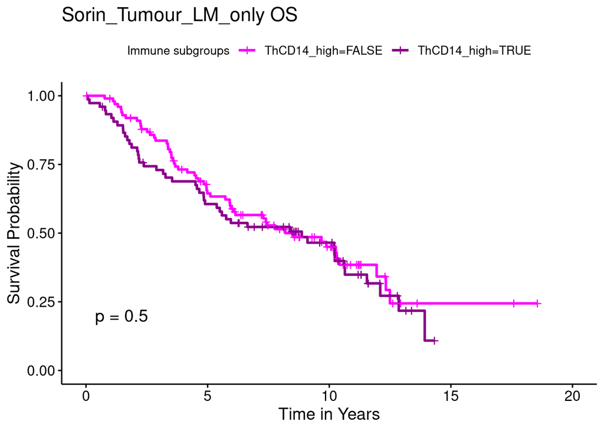

```
                              group median_survival lower_ci upper_ci
ThCD14_high=FALSE ThCD14_high=FALSE           8.545    5.952   11.948
ThCD14_high=TRUE   ThCD14_high=TRUE           8.871    5.375   11.548
```

```
Call:
coxph(formula = form, data = data_fr)

  n= 176, number of events= 102
   (12 observations deleted due to missingness)

                  coef exp(coef) se(coef)     z Pr(>|z|)
ThCD14_highTRUE 0.1329    1.1422   0.1991 0.668    0.504

                exp(coef) exp(-coef) lower .95 upper .95
ThCD14_highTRUE     1.142     0.8755    0.7731     1.687

Concordance= 0.526  (se = 0.027 )
Likelihood ratio test= 0.44  on 1 df,   p=0.5
Wald test            = 0.45  on 1 df,   p=0.5
Score (logrank) test = 0.45  on 1 df,   p=0.5
```

```r
> do_survival_analysis(survival_Sorin_cohort[survival_Sorin_cohort$immuneSubgroups == "LM",],
+                      "ThCD14_high", "OS", output_folder, "Sorin_Tumour_LM_only")
```

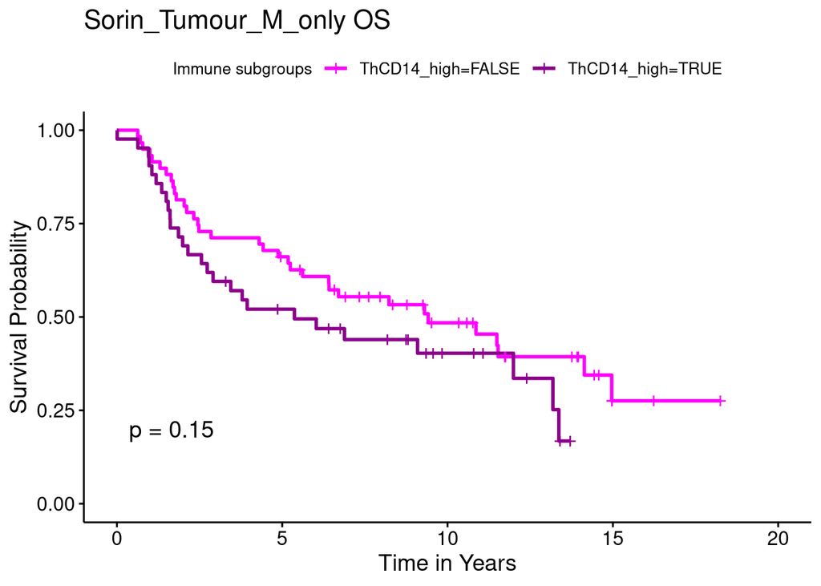

```
                              group median_survival lower_ci upper_ci
ThCD14_high=FALSE ThCD14_high=FALSE           9.416    5.615       NA
ThCD14_high=TRUE   ThCD14_high=TRUE           5.369    2.730       NA
```

```
Call:
coxph(formula = form, data = data_fr)

  n= 101, number of events= 61
   (14 observations deleted due to missingness)

                  coef exp(coef) se(coef)     z Pr(>|z|)
ThCD14_highTRUE 0.3756    1.4558   0.2623 1.432    0.152

                exp(coef) exp(-coef) lower .95 upper .95
ThCD14_highTRUE     1.456     0.6869    0.8707     2.434

Concordance= 0.547  (se = 0.034 )
Likelihood ratio test= 2.02  on 1 df,   p=0.2
Wald test            = 2.05  on 1 df,   p=0.2
Score (logrank) test = 2.07  on 1 df,   p=0.1
```

```r
> do_survival_analysis(survival_Sorin_cohort[survival_Sorin_cohort$immuneSubgroups == "M",],
+                      "ThCD14_high", "OS", output_folder, "Sorin_Tumour_M_only")
```

### 4.4.1 By stage

First, get the data about stage: Stage (I-II: 0, III-IV:1)

```r
> Sorin_full_patient_info <- readRDS("../../data/Sorin_full_patient_info.rds")
>
> survival_Sorin_cohort$Stage <- Sorin_full_patient_info$`Stage (I-II: 0, III-IV:1)`[match(survival_Sorin_cohort$Patient, Sorin_full_patient_info$SampleId)]
> table(survival_Sorin_cohort$Stage)
```

```
  0   1
365  50
```

```r
> table(survival_Sorin_cohort$Stage, survival_Sorin_cohort$immuneSubgroups)
```

```
      L  LM   M
  0 106 165  94
  1   7  22  21
```

```r
> round(prop.table(table(survival_Sorin_cohort$Stage,
+                  as.character(survival_Sorin_cohort$immuneSubgroups)),
+                  margin = 2),
+       digits = 2)
```

```
       L   LM    M
  0 0.94 0.88 0.82
  1 0.06 0.12 0.18
```

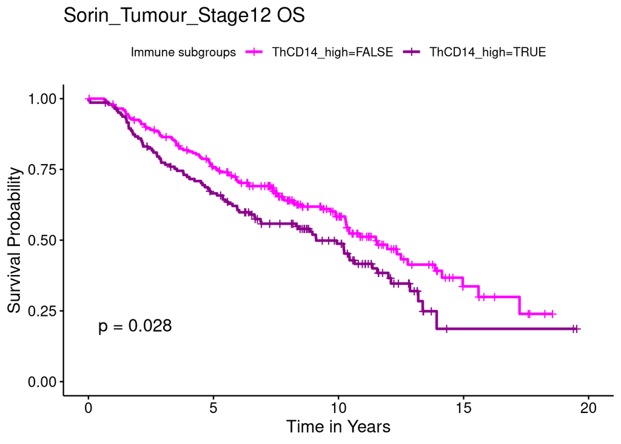

```
                              group median_survival lower_ci upper_ci
ThCD14_high=FALSE ThCD14_high=FALSE          11.491   10.286   14.136
ThCD14_high=TRUE   ThCD14_high=TRUE           9.104    6.661   11.548
```

```
Call:
coxph(formula = form, data = data_fr)

  n= 345, number of events= 175
   (21 observations deleted due to missingness)

                  coef exp(coef) se(coef)     z Pr(>|z|)
ThCD14_highTRUE 0.3333    1.3956   0.1522 2.191   0.0285 *
---
Signif. codes:  0 '***' 0.001 '**' 0.01 '*' 0.05 '.' 0.1 ' ' 1

                exp(coef) exp(-coef) lower .95 upper .95
ThCD14_highTRUE     1.396     0.7165     1.036     1.881

Concordance= 0.545  (se = 0.02 )
Likelihood ratio test= 4.75  on 1 df,   p=0.03
Wald test            = 4.8  on 1 df,   p=0.03
Score (logrank) test = 4.84  on 1 df,   p=0.03
```

```r
> do_survival_analysis(survival_Sorin_cohort[survival_Sorin_cohort$Stage == 0,],
+                      "ThCD14_high", "OS", output_folder, "Sorin_Tumour_Stage12")
```

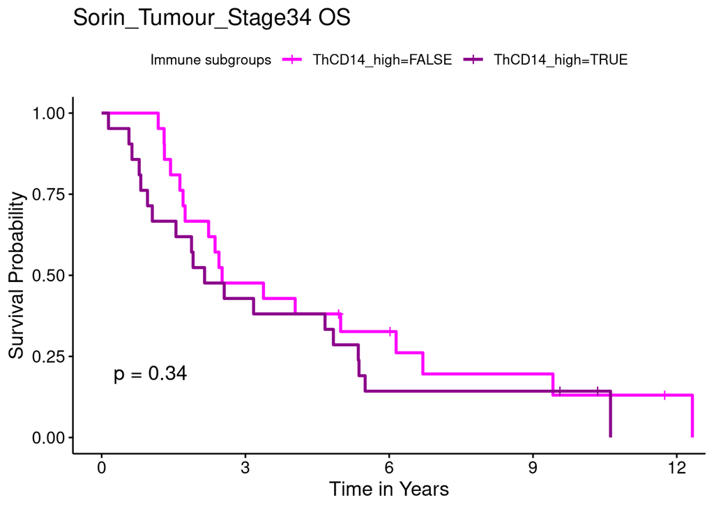

```
                              group median_survival lower_ci upper_ci
ThCD14_high=FALSE ThCD14_high=FALSE           2.513    1.741    9.416
ThCD14_high=TRUE   ThCD14_high=TRUE           2.147    1.057    5.369
```

```
Call:
coxph(formula = form, data = data_fr)

  n= 42, number of events= 37
   (9 observations deleted due to missingness)

                  coef exp(coef) se(coef)     z Pr(>|z|)
ThCD14_highTRUE 0.3175    1.3737   0.3348 0.948    0.343

                exp(coef) exp(-coef) lower .95 upper .95
ThCD14_highTRUE     1.374     0.7279    0.7127     2.648

Concordance= 0.558  (se = 0.046 )
Likelihood ratio test= 0.9  on 1 df,   p=0.3
Wald test            = 0.9  on 1 df,   p=0.3
Score (logrank) test = 0.91  on 1 df,   p=0.3
```

```r
> do_survival_analysis(survival_Sorin_cohort[survival_Sorin_cohort$Stage == 1,],
+                      "ThCD14_high", "OS", output_folder, "Sorin_Tumour_Stage34")
```

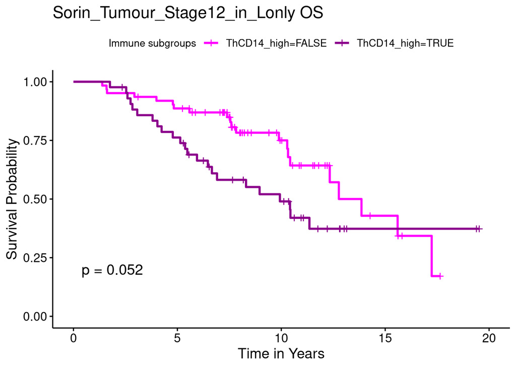

```
                              group median_survival lower_ci upper_ci
ThCD14_high=FALSE ThCD14_high=FALSE          13.859   12.332       NA
ThCD14_high=TRUE   ThCD14_high=TRUE           9.933    6.661       NA
```

```
Call:
coxph(formula = form, data = data_fr)

  n= 105, number of events= 44
   (1 observation deleted due to missingness)

                  coef exp(coef) se(coef)     z Pr(>|z|)
ThCD14_highTRUE 0.5807    1.7873   0.3033 1.915   0.0555 .
---
Signif. codes:  0 '***' 0.001 '**' 0.01 '*' 0.05 '.' 0.1 ' ' 1

                exp(coef) exp(-coef) lower .95 upper .95
ThCD14_highTRUE     1.787     0.5595    0.9864     3.238

Concordance= 0.607  (se = 0.041 )
Likelihood ratio test= 3.65  on 1 df,   p=0.06
Wald test            = 3.67  on 1 df,   p=0.06
Score (logrank) test = 3.77  on 1 df,   p=0.05
```

```r
> do_survival_analysis(survival_Sorin_cohort[survival_Sorin_cohort$Stage == 0 & survival_Sorin_cohort$immuneSubgroups == "L",],
+                      "ThCD14_high", "OS", output_folder, "Sorin_Tumour_Stage12_in_Lonly")
```

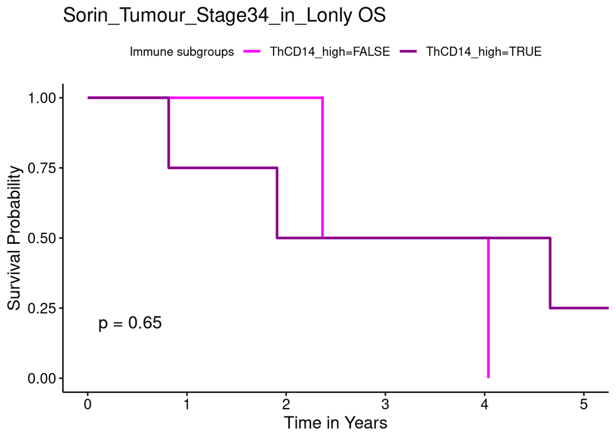

```
                              group median_survival lower_ci upper_ci
ThCD14_high=FALSE ThCD14_high=FALSE           3.202    2.366       NA
ThCD14_high=TRUE   ThCD14_high=TRUE           3.284    0.816       NA
```

```
Call:
coxph(formula = form, data = data_fr)

  n= 6, number of events= 6
   (1 observation deleted due to missingness)

                   coef exp(coef) se(coef)      z Pr(>|z|)
ThCD14_highTRUE -0.4492    0.6381   1.0100 -0.445    0.657

                exp(coef) exp(-coef) lower .95 upper .95
ThCD14_highTRUE    0.6381      1.567   0.08815      4.62

Concordance= 0.5  (se = 0.133 )
Likelihood ratio test= 0.2  on 1 df,   p=0.7
Wald test            = 0.2  on 1 df,   p=0.7
Score (logrank) test = 0.2  on 1 df,   p=0.7
```

```r
> do_survival_analysis(survival_Sorin_cohort[survival_Sorin_cohort$Stage == 1 & survival_Sorin_cohort$immuneSubgroups == "L",],
+                      "ThCD14_high", "OS", output_folder, "Sorin_Tumour_Stage34_in_Lonly")
```

### 4.4.2 By histology

```r
> survival_Sorin_cohort$histology <- Sorin_full_patient_info$`Predominant histological pattern (Lepidic:1, Papillary: 2, Acinar: 3, Micropapillary: 4, Solid: 5)`[match(survival_Sorin_cohort$Patient, Sorin_full_patient_info$SampleId)]
>
>
> survival_Sorin_cohort <- survival_Sorin_cohort %>%
+   mutate(
+     hist =  case_when(
+     histology == 1 ~ "Lepidic",
+     histology == 2 ~ "Papillary",
+     histology == 3 ~ "Acinar",
+     histology == 4 ~ "Micropapillary",
+     histology == 5 ~ "Solid",
+     .default = as.character(histology)
+   )
+   )
> table(survival_Sorin_cohort$hist)
```

```
        Acinar        Lepidic Micropapillary      Papillary          Solid
           190             40             35             33            118
```

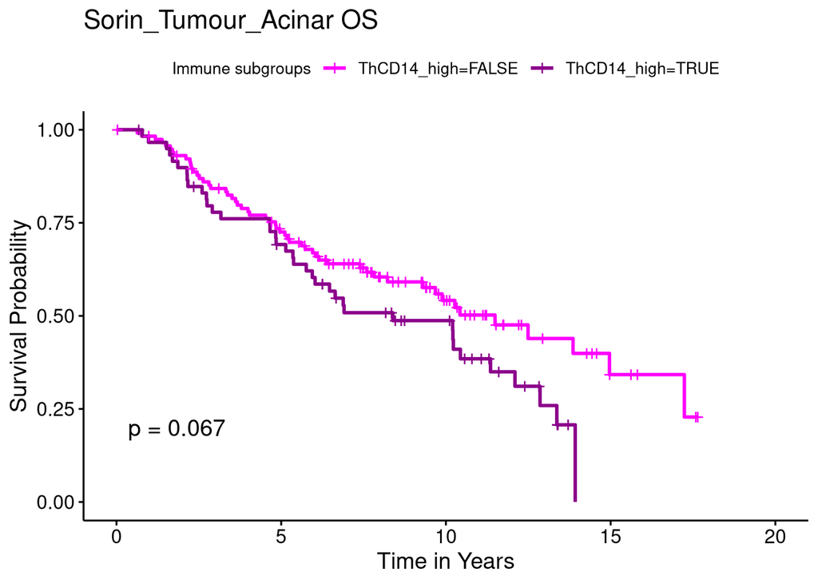

```
                              group median_survival lower_ci upper_ci
ThCD14_high=FALSE ThCD14_high=FALSE          11.491    9.301       NA
ThCD14_high=TRUE   ThCD14_high=TRUE           8.386    5.944   12.096
```

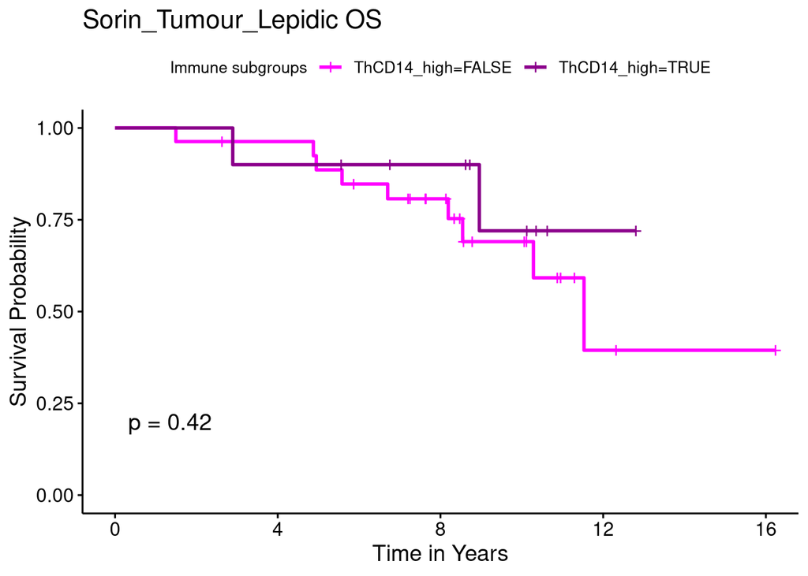

```
                              group median_survival lower_ci upper_ci
ThCD14_high=FALSE ThCD14_high=FALSE          11.529   10.286       NA
ThCD14_high=TRUE   ThCD14_high=TRUE              NA    8.956       NA
```

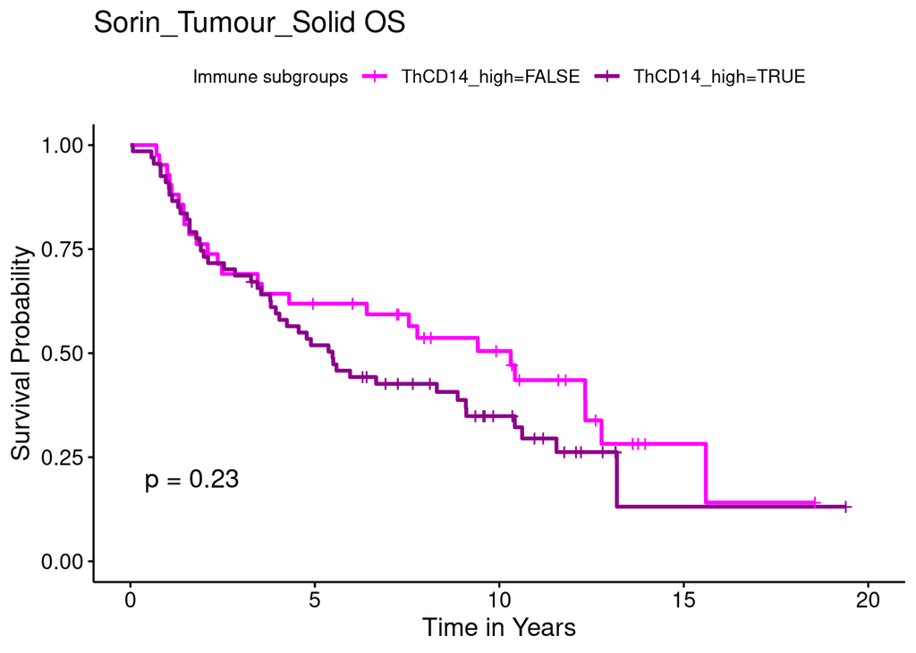

```
                              group median_survival lower_ci upper_ci
ThCD14_high=FALSE ThCD14_high=FALSE          10.308    4.301       NA
ThCD14_high=TRUE   ThCD14_high=TRUE           5.479    3.940    9.104
```

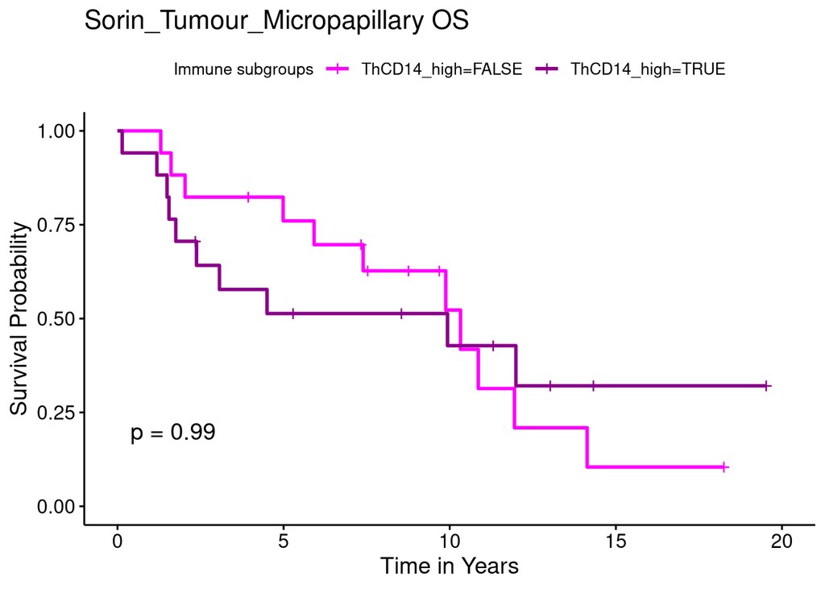

```
                              group median_survival lower_ci upper_ci
ThCD14_high=FALSE ThCD14_high=FALSE          10.325    7.395       NA
ThCD14_high=TRUE   ThCD14_high=TRUE           9.933    2.379       NA
```

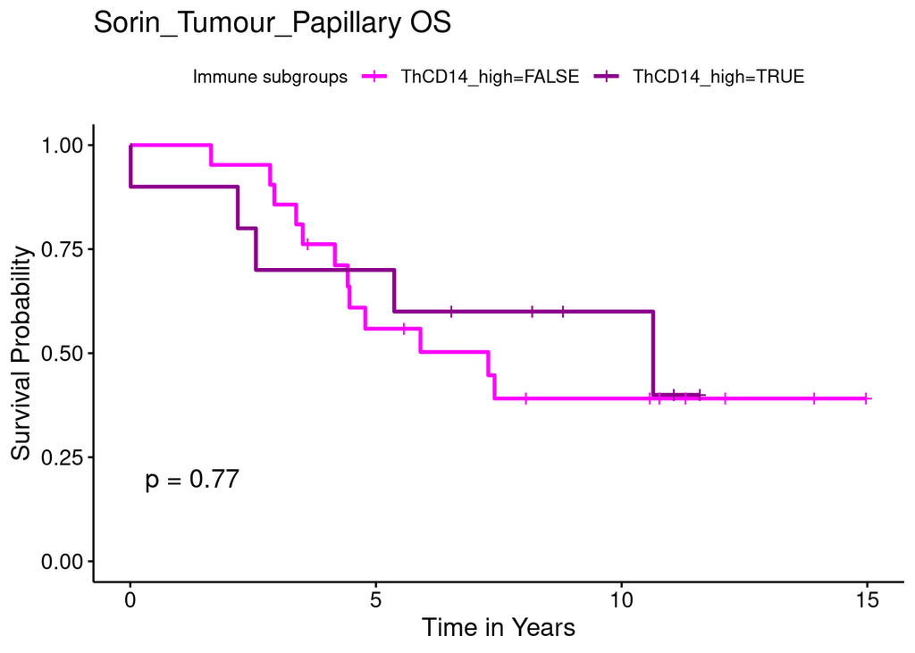

```
                              group median_survival lower_ci upper_ci
ThCD14_high=FALSE ThCD14_high=FALSE           7.286    4.424       NA
ThCD14_high=TRUE   ThCD14_high=TRUE          10.642    2.557       NA
```

```r
> for (hist in unique(survival_Sorin_cohort$hist)) {
+   do_survival_analysis(survival_Sorin_cohort[survival_Sorin_cohort$hist == hist,],
+                      "ThCD14_high", "OS", output_folder, paste0("Sorin_Tumour_", hist))
+ }
```

## 4.5 Info for supp table 9

Here Claire asked to take only L subgroup.

```r
> sorin_L_CD14hign_vs_low <- survival_Sorin_cohort[survival_Sorin_cohort$immuneSubgroups == "L",
+                                                              c("Patient", "Percentage", "ThCD14_high")]
>
> #Sorin_full_patient_info <- Sorin_full_patient_info[,c(1, 19:28)]
>
> patient_info_sorinL <- left_join(sorin_L_CD14hign_vs_low, Sorin_full_patient_info, by = c("Patient" = "SampleId"))
>
> tab <- table(patient_info_sorinL$ThCD14_high, patient_info_sorinL$`Sex (Male: 0, Female: 1)`)
> fisher.test(tab)
```

```
    Fisher's Exact Test for Count Data

data:  tab
p-value = 0.2391
alternative hypothesis: true odds ratio is not equal to 1
95 percent confidence interval:
 0.2566223 1.3820604
sample estimates:
odds ratio
 0.5980626
```

```r
> tab <- table(patient_info_sorinL$ThCD14_high, patient_info_sorinL$`Age (<75: 0, ≥75: 1)`)
> fisher.test(tab)
```

```
    Fisher's Exact Test for Count Data

data:  tab
p-value = 0.7405
alternative hypothesis: true odds ratio is not equal to 1
95 percent confidence interval:
 0.3016313 6.5054506
sample estimates:
odds ratio
  1.400371
```

```r
> tab <- table(patient_info_sorinL$ThCD14_high, patient_info_sorinL$`BMI (<30: 0, ≥30: 1)`)
> fisher.test(tab)
```

```
    Fisher's Exact Test for Count Data

data:  tab
p-value = 0.4458
alternative hypothesis: true odds ratio is not equal to 1
95 percent confidence interval:
 0.1799484 2.0249912
sample estimates:
odds ratio
 0.6366859
```

```r
> tab <- table(patient_info_sorinL$ThCD14_high, patient_info_sorinL$`Smoking Status (Smoker: 0, Non-smoker:1)`)
> fisher.test(tab)
```

```
    Fisher's Exact Test for Count Data

data:  tab
p-value = 1
alternative hypothesis: true odds ratio is not equal to 1
95 percent confidence interval:
 0.1756175 4.0662705
sample estimates:
odds ratio
 0.9001067
```

```r
> tab <- table(patient_info_sorinL$ThCD14_high, patient_info_sorinL$`Stage (I-II: 0, III-IV:1)`)
> fisher.test(tab)
```

```
    Fisher's Exact Test for Count Data

data:  tab
p-value = 0.3983
alternative hypothesis: true odds ratio is not equal to 1
95 percent confidence interval:
  0.3895464 32.9045232
sample estimates:
odds ratio
  2.856149
```

```r
> cols_of_intr <- c('Sex (Male: 0, Female: 1)','Age (<75: 0, ≥75: 1)', 'BMI (<30: 0, ≥30: 1)',  'Smoking Status (Smoker: 0, Non-smoker:1)',
+                   'Stage (I-II: 0, III-IV:1)', 'Predominant histological pattern (Lepidic:1, Papillary: 2, Acinar: 3, Micropapillary: 4, Solid: 5)')
>
> for (col in cols_of_intr) {
+   tabe <- table(patient_info_sorinL$ThCD14_high, patient_info_sorinL[[col]])
+ }
>
> # Total number of patients
> total_patients <- nrow(patient_info_sorinL)
>
> # Compute % of total for each category, stratified by ThCD14_high
> df_summary <- patient_info_sorinL %>%
+   group_by(ThCD14_high) %>%
+   summarise(
+     Patients_in_group = n(),
+
+     Female_pct = sum(`Sex (Male: 0, Female: 1)` == 1) / Patients_in_group * 100,
+     Male_pct = sum(`Sex (Male: 0, Female: 1)` == 0) / Patients_in_group * 100,
+
+     Age75plus_pct = sum(`Age (<75: 0, ≥75: 1)` == 1) / Patients_in_group * 100,
+     AgeUnder75_pct = sum(`Age (<75: 0, ≥75: 1)` == 0) / Patients_in_group * 100,
+
+     BMI30plus_pct = sum(`BMI (<30: 0, ≥30: 1)` == 1) / Patients_in_group * 100,
+     BMIunder30_pct = sum(`BMI (<30: 0, ≥30: 1)` == 0) / Patients_in_group * 100,
+
+     Smoker_pct = sum(`Smoking Status (Smoker: 0, Non-smoker:1)` == 0) / Patients_in_group * 100,
+     NonSmoker_pct = sum(`Smoking Status (Smoker: 0, Non-smoker:1)` == 1) / Patients_in_group * 100,
+
+     Stage34_pct = sum(`Stage (I-II: 0, III-IV:1)` == 1) / Patients_in_group * 100,
+     Stage12_pct = sum(`Stage (I-II: 0, III-IV:1)` == 0) / Patients_in_group * 100
+   )
>
> df_summary
```

```
# A tibble: 3 × 12
  ThCD14_high Patients_in_group Female_pct Male_pct Age75plus_pct AgeUnder75_pct
  <lgl>                   <int>      <dbl>    <dbl>         <dbl>          <dbl>
1 FALSE                      64       65.6     34.4          7.81           92.2
2 TRUE                       47       53.2     46.8         10.6            89.4
3 NA                          2      100        0           50              50
# ℹ 6 more variables: BMI30plus_pct <dbl>, BMIunder30_pct <dbl>,
#   Smoker_pct <dbl>, NonSmoker_pct <dbl>, Stage34_pct <dbl>, Stage12_pct <dbl>
```

```r
> # Create contingency table: rows = ThCD14_high, columns = sex (0 = Male, 1 = Female)
> tab <- table(patient_info_sorinL$ThCD14_high, patient_info_sorinL$`Sex (Male: 0, Female: 1)`)
>
> # Perform Fisher's Exact Test
> fisher.test(tab)
```

```
    Fisher's Exact Test for Count Data

data:  tab
p-value = 0.2391
alternative hypothesis: true odds ratio is not equal to 1
95 percent confidence interval:
 0.2566223 1.3820604
sample estimates:
odds ratio
 0.5980626
```

```r
> patient_info_sorinL <- patient_info_sorinL
> hist_def <- colnames(patient_info_sorinL)[13]
> colnames(patient_info_sorinL)[startsWith(colnames(patient_info_sorinL), "Predominant")] <- "histology"
> patient_info_sorinL <- patient_info_sorinL %>%
+   mutate(
+     hist =  case_when(
+     histology == 1 ~ "Lepidic",
+     histology == 2 ~ "Papillary",
+     histology == 3 ~ "Acinar",
+     histology == 4 ~ "Micropapillary",
+     histology == 5 ~ "Solid",
+     .default = as.character(histology)
+   )
+   )
>
> df_summary <- patient_info_sorinL %>%
+   group_by(ThCD14_high) %>%
+   summarise(
+     Patients_in_group = n(),
+
+     Lepidic_pct = sum(hist == "Lepidic") / Patients_in_group * 100,
+     Papillary_pct = sum(hist == "Papillary") / Patients_in_group * 100,
+     Acinar_pct = sum(hist == "Acinar") / Patients_in_group * 100,
+     Micropapillary_pct = sum(hist == "Micropapillary") / Patients_in_group * 100,
+     Solid_pct = sum(hist == "Solid") / Patients_in_group * 100
+   )
>
> # Create contingency table: rows = ThCD14_high, columns = sex (0 = Male, 1 = Female)
> tab <- table(patient_info_sorinL$ThCD14_high, patient_info_sorinL$hist)
>
> # Chi-squared test
> chisq.test(tab)
```

```
    Pearson's Chi-squared test

data:  tab
X-squared = 13.304, df = 4, p-value = 0.009883
```

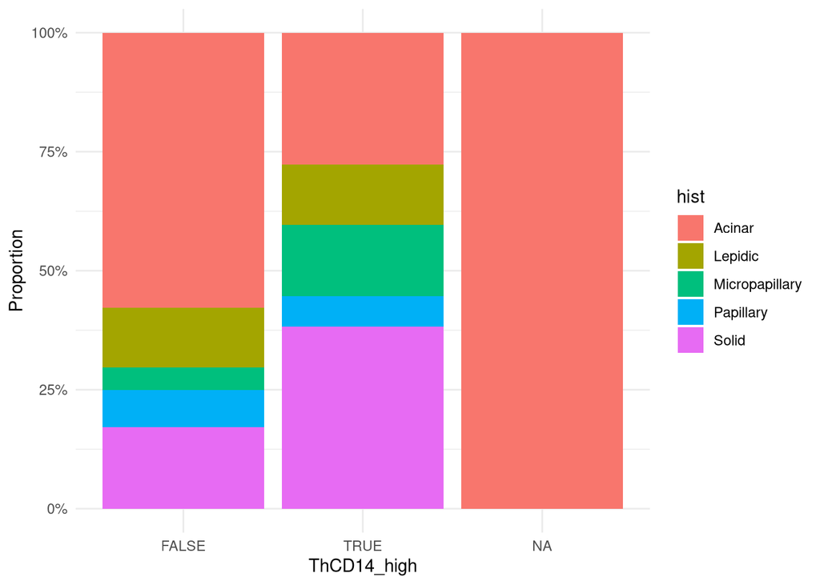

```r
> ggplot(patient_info_sorinL, aes(x = ThCD14_high, fill = hist)) +
+   geom_bar(position = "fill") +  # shows proportions
+   ylab("Proportion") +
+   scale_y_continuous(labels = scales::percent) +
+   theme_minimal()
```

```r
> # Unique histology types
> types <- unique(patient_info_sorinL$hist)
>
> # Run Fisher's test for each histology type and collect p-values
> pvals <- map_dfr(types, function(h) {
+   # Create 2x2 table: rows = ThCD14_high, cols = this histology vs others
+   tab <- table(patient_info_sorinL$ThCD14_high, patient_info_sorinL$hist == h)
+
+   # Only run test if table has 2 rows and 2 columns
+   if (all(dim(tab) == c(2, 2))) {
+     p <- fisher.test(tab)$p.value
+   } else {
+     p <- NA
+   }
+
+   tibble(hist = h, p = p)
+ }) %>%
+   mutate(p_adj = p.adjust(p, method = "BH"))
>
> pvals
```

```
# A tibble: 5 × 3
  hist                 p  p_adj
  <chr>            <dbl>  <dbl>
1 Micropapillary 0.0930  0.155
2 Acinar         0.00201 0.0100
3 Papillary      1       1
4 Solid          0.0163  0.0407
5 Lepidic        1       1
```

# 5 Enfield

## 5.1 Prepare the table

```r
> survival_Enfield_cohort <- patient_survival_Enfield[,c("cruk_id", "histology_multi_full",
+                                                        "os_time", "cens_os",
+                                                        "dfs_time", "cens_dfs")]
>
> survival_Enfield_cohort$OS_years <- round(survival_Enfield_cohort$os_time/365.25, 2)
> survival_Enfield_cohort$Death <- as.logical(survival_Enfield_cohort$cens_os) # censored 1=death, 0=alive
> survival_Enfield_cohort$RFS_years <- round(survival_Enfield_cohort$dfs_time/365.25, 2)
> survival_Enfield_cohort$Relapse <- as.logical(survival_Enfield_cohort$cens_dfs)
>
> head(survival_Enfield_cohort)
```

```
   cruk_id histology_multi_full os_time cens_os dfs_time cens_dfs OS_years
1 CRUK0034                 LUAD    1849       0     1849        0     5.06
4 CRUK0090                 LUSC    2365       0     1143        1     6.48
5 CRUK0045                 LUAD     986       1      917        1     2.70
6 CRUK0076                 LUSC    1934       0     1934        0     5.30
7 CRUK0063                 LUSC     858       1      456        1     2.35
8 CRUK0005                 LUAD     649       1      649        1     1.78
  Death RFS_years Relapse
1 FALSE      5.06   FALSE
4 FALSE      3.13    TRUE
5  TRUE      2.51    TRUE
6 FALSE      5.30   FALSE
7  TRUE      1.25    TRUE
8  TRUE      1.78    TRUE
```

```r
> table(patient_survival_Enfield$histology_multi_full)
```

```
  LUAD LUADx2   LUSC  Other
    56      3     31      8
```

```r
> survival_Enfield_LUAD <- survival_Enfield_cohort[startsWith(survival_Enfield_cohort$histology_multi_full, "LUAD"),]
>
> survival_Enfield_LUAD$immuneSubgroups <- Enfield_LUAD_immune_subgr$cluster[match(survival_Enfield_LUAD$cruk_id,
+                                                                                        Enfield_LUAD_immune_subgr$patient)]
> survival_Enfield_LUAD$immuneSubgroups <- factor(survival_Enfield_LUAD$immuneSubgroups, levels = c("L", "LM", "M"))
```

## 5.2 OS LUAD

```r
> table(survival_Enfield_LUAD$immuneSubgroups)
```

```
 L LM  M
16 15  8
```

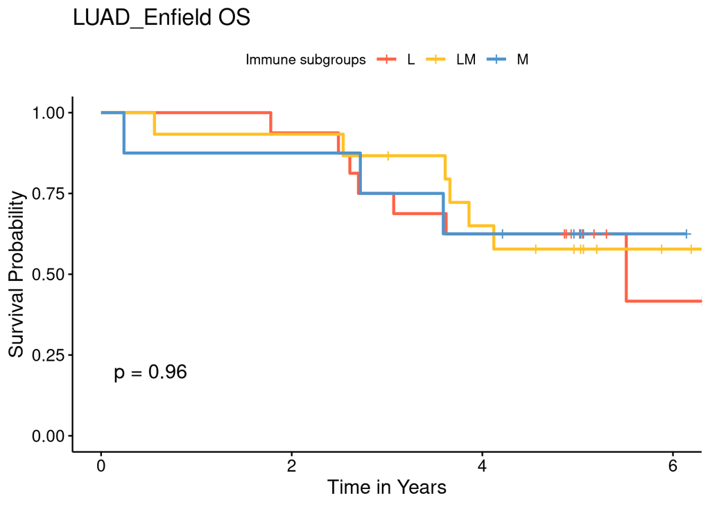

```
                                group median_survival lower_ci upper_ci
immuneSubgroups=L   immuneSubgroups=L            5.51     3.07       NA
immuneSubgroups=LM immuneSubgroups=LM              NA     3.86       NA
immuneSubgroups=M   immuneSubgroups=M              NA     3.59       NA
```

```
Call:
coxph(formula = form, data = data_fr)

  n= 39, number of events= 16
   (20 observations deleted due to missingness)

                      coef exp(coef) se(coef)      z Pr(>|z|)
immuneSubgroupsLM -0.02493   0.97538  0.70769 -0.035    0.972
immuneSubgroupsL   0.11927   1.12668  0.69066  0.173    0.863

                  exp(coef) exp(-coef) lower .95 upper .95
immuneSubgroupsLM    0.9754     1.0252    0.2437     3.904
immuneSubgroupsL     1.1267     0.8876    0.2910     4.362

Concordance= 0.517  (se = 0.069 )
Likelihood ratio test= 0.07  on 2 df,   p=1
Wald test            = 0.07  on 2 df,   p=1
Score (logrank) test = 0.07  on 2 df,   p=1
```

```r
> do_survival_analysis(survival_Enfield_LUAD, "immuneSubgroups", "OS",
+                      output_folder, plot_title = "LUAD_Enfield")
```

## 5.3 RFS LUAD

```r
> table(is.na(survival_Enfield_LUAD$RFS_years), survival_Enfield_LUAD$immuneSubgroups)
```

```
         L LM  M
  FALSE 16 15  8
```

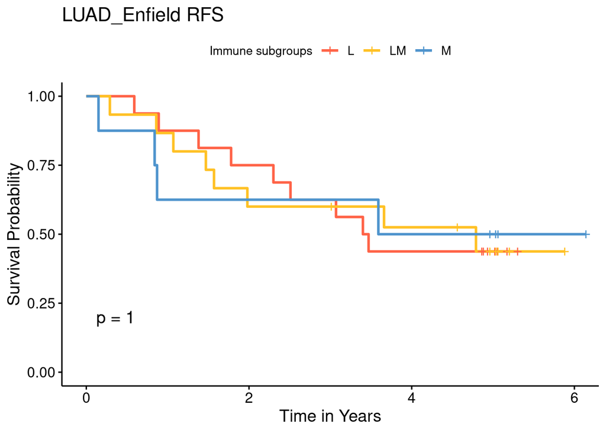

```
                                group median_survival lower_ci upper_ci
immuneSubgroups=L   immuneSubgroups=L           3.435     2.30       NA
immuneSubgroups=LM immuneSubgroups=LM           4.790     1.57       NA
immuneSubgroups=M   immuneSubgroups=M           3.590     0.87       NA
```

```
Call:
coxph(formula = form, data = data_fr)

  n= 39, number of events= 21
   (20 observations deleted due to missingness)

                     coef exp(coef) se(coef)     z Pr(>|z|)
immuneSubgroupsLM 0.01642   1.01655  0.61341 0.027    0.979
immuneSubgroupsL  0.02251   1.02277  0.60248 0.037    0.970

                  exp(coef) exp(-coef) lower .95 upper .95
immuneSubgroupsLM     1.017     0.9837    0.3055     3.383
immuneSubgroupsL      1.023     0.9777    0.3140     3.331

Concordance= 0.482  (se = 0.066 )
Likelihood ratio test= 0  on 2 df,   p=1
Wald test            = 0  on 2 df,   p=1
Score (logrank) test = 0  on 2 df,   p=1
```

```r
> do_survival_analysis(survival_Enfield_LUAD, "immuneSubgroups", "RFS",
+                      output_folder, plot_title = "LUAD_Enfield")
```

## 5.4 CD4CD14 high vs low

```r
> Percentage_Enfield_cohort_Tumour_CD4CD14 <- readRDS("../../Figure2/interim_data/Percentage_Enfield_cohort_Tumour_ThCD14.rds")
> threshold_Enfield_CD4CD14_Tumour <- mean(Percentage_Enfield_cohort_Tumour_CD4CD14$PercentageCD4CD14)
> threshold_Enfield_CD4CD14_Tumour
```

```
[1] 18.67168
```

```r
> survival_Enfield_LUAD_filt <- survival_Enfield_LUAD[survival_Enfield_LUAD$cruk_id %in% Percentage_Enfield_cohort_Tumour_CD4CD14$Patient,]
>
> survival_Enfield_LUAD_filt$PercentageCD4CD14 <- Percentage_Enfield_cohort_Tumour_CD4CD14$PercentageCD4CD14[match(
+   survival_Enfield_LUAD_filt$cruk_id, Percentage_Enfield_cohort_Tumour_CD4CD14$Patient
+ )]
>
> survival_Enfield_LUAD_filt$ThCD14_high <- survival_Enfield_LUAD_filt$PercentageCD4CD14 > threshold_Enfield_CD4CD14_Tumour
> table(survival_Enfield_LUAD_filt$ThCD14_high, survival_Enfield_LUAD_filt$immuneSubgroups)
```

```
         L LM  M
  FALSE 10  6  5
  TRUE   5  9  1
```

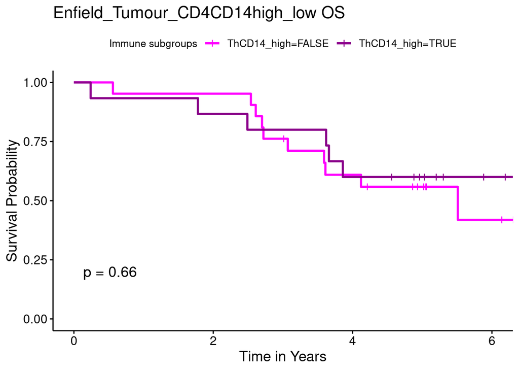

```
                              group median_survival lower_ci upper_ci
ThCD14_high=FALSE ThCD14_high=FALSE            5.51     3.59       NA
ThCD14_high=TRUE   ThCD14_high=TRUE              NA     3.66       NA
```

```
Call:
coxph(formula = form, data = data_fr)

  n= 36, number of events= 16

                   coef exp(coef) se(coef)      z Pr(>|z|)
ThCD14_highTRUE -0.2287    0.7956   0.5177 -0.442    0.659

                exp(coef) exp(-coef) lower .95 upper .95
ThCD14_highTRUE    0.7956      1.257    0.2884     2.195

Concordance= 0.516  (se = 0.067 )
Likelihood ratio test= 0.2  on 1 df,   p=0.7
Wald test            = 0.2  on 1 df,   p=0.7
Score (logrank) test = 0.2  on 1 df,   p=0.7
```

```r
> do_survival_analysis(survival_Enfield_LUAD_filt,
+                      "ThCD14_high", "OS", output_folder, "Enfield_Tumour_CD4CD14high_low")
```

# 6 All data sets together

```r
> cols_of_intrest <- c("immuneSubgroups", "OS_years", "Death", "ThCD14_high")
> survival_CM_LUAD_LLM <- survival_CM_LUAD_LLM[, cols_of_intrest]
> #survival_CM_LUAD <- survival_CM_LUAD[, cols_of_intrest]
> survival_Sorin_cohort <- survival_Sorin_cohort[, cols_of_intrest]
> #survival_Enfield_LUAD <- survival_Enfield_LUAD[, cols_of_intrest]
> survival_Enfield_LUAD_filt <- survival_Enfield_LUAD_filt[,cols_of_intrest]
>
> survival_all <- rbind(survival_CM_LUAD_LLM, survival_Enfield_LUAD_filt, survival_Sorin_cohort)
>
> survival_LLM <- survival_all[survival_all$immuneSubgroups != "M",]
>
> #do_survival_analysis(survival_all, "immuneSubgroups", "OS",
> #                     output_folder, plot_title = "ALL_data_sets_together")
```

## 6.1 Split by CD14+ high and low

L+LM

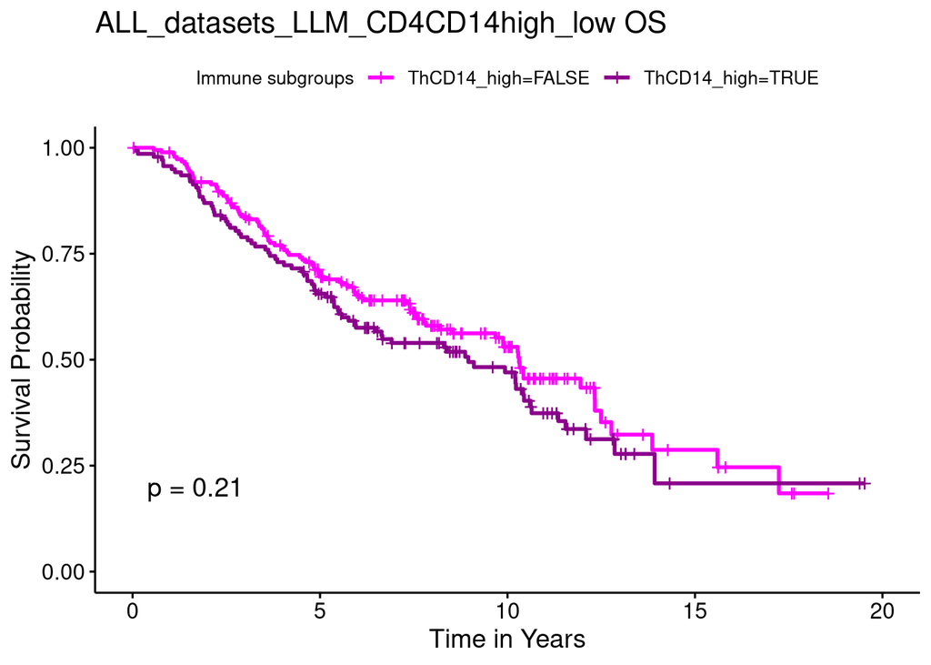

```
                              group median_survival lower_ci upper_ci
ThCD14_high=FALSE ThCD14_high=FALSE          10.308    8.192   12.493
ThCD14_high=TRUE   ThCD14_high=TRUE           8.956    5.955   10.618
```

```
Call:
coxph(formula = form, data = data_fr)

  n= 326, number of events= 170
   (40 observations deleted due to missingness)

                  coef exp(coef) se(coef)     z Pr(>|z|)
ThCD14_highTRUE 0.1927    1.2126   0.1540 1.252    0.211

                exp(coef) exp(-coef) lower .95 upper .95
ThCD14_highTRUE     1.213     0.8247    0.8967      1.64

Concordance= 0.528  (se = 0.021 )
Likelihood ratio test= 1.56  on 1 df,   p=0.2
Wald test            = 1.57  on 1 df,   p=0.2
Score (logrank) test = 1.57  on 1 df,   p=0.2
```

```r
> do_survival_analysis(survival_LLM,
+                      "ThCD14_high", "OS", output_folder, "ALL_datasets_LLM_CD4CD14high_low")
```

L only

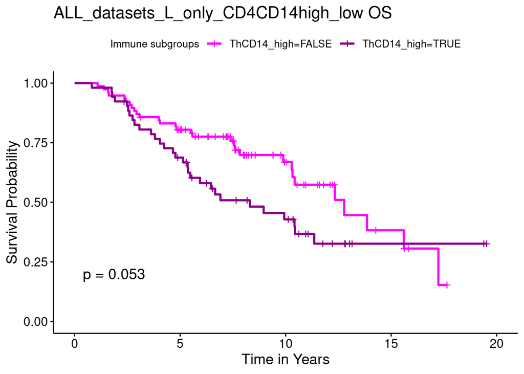

```
                              group median_survival lower_ci upper_ci
ThCD14_high=FALSE ThCD14_high=FALSE          12.770   10.325       NA
ThCD14_high=TRUE   ThCD14_high=TRUE           8.304    5.479       NA
```

```
Call:
coxph(formula = form, data = data_fr)

  n= 129, number of events= 60
   (18 observations deleted due to missingness)

                  coef exp(coef) se(coef)     z Pr(>|z|)
ThCD14_highTRUE 0.4967    1.6433   0.2591 1.917   0.0553 .
---
Signif. codes:  0 '***' 0.001 '**' 0.01 '*' 0.05 '.' 0.1 ' ' 1

                exp(coef) exp(-coef) lower .95 upper .95
ThCD14_highTRUE     1.643     0.6085    0.9889     2.731

Concordance= 0.579  (se = 0.035 )
Likelihood ratio test= 3.64  on 1 df,   p=0.06
Wald test            = 3.67  on 1 df,   p=0.06
Score (logrank) test = 3.75  on 1 df,   p=0.05
```

```r
> do_survival_analysis(survival_LLM[survival_LLM$immuneSubgroups == "L",],
+                      "ThCD14_high", "OS", output_folder, "ALL_datasets_L_only_CD4CD14high_low")
```

LM only

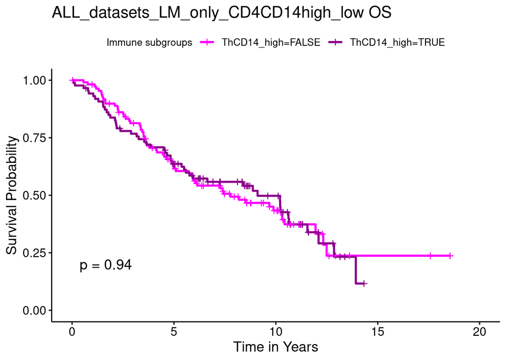

```
                              group median_survival lower_ci upper_ci
ThCD14_high=FALSE ThCD14_high=FALSE           7.776    5.906   11.948
ThCD14_high=TRUE   ThCD14_high=TRUE           9.104    5.761   12.096
```

```
Call:
coxph(formula = form, data = data_fr)

  n= 197, number of events= 110
   (22 observations deleted due to missingness)

                    coef exp(coef) se(coef)      z Pr(>|z|)
ThCD14_highTRUE -0.01436   0.98574  0.19203 -0.075     0.94

                exp(coef) exp(-coef) lower .95 upper .95
ThCD14_highTRUE    0.9857      1.014    0.6766     1.436

Concordance= 0.499  (se = 0.026 )
Likelihood ratio test= 0.01  on 1 df,   p=0.9
Wald test            = 0.01  on 1 df,   p=0.9
Score (logrank) test = 0.01  on 1 df,   p=0.9
```

```r
> do_survival_analysis(survival_LLM[survival_LLM$immuneSubgroups == "LM",],
+                      "ThCD14_high", "OS", output_folder, "ALL_datasets_LM_only_CD4CD14high_low")
```